# 2039 Project

Yuxin Ren & Nuo Wei

12/04/2022

# 1 Summary

We focus on a worldwide public health issue, obesity, based on the data from the Natural Center for Health Statistics in 2017-2018 (NHNES 17-18). The research questions are

1. Does an elder age imply a higher BMI?
2. Does a lower income indicate a higher BMI?
3. Does a long sedentary activity lead to a higher BMI?
4. Does a higher BMI result in a higher SBP/DBP?
5. Does a higher BMI cause a higher total cholesterol?

The variables we selected included as follows:

1. BMXBMI > 30 (categorical)
2. RIDAGEYR - age in years at screening (quantitative)
3. INDFMMPC - family monthly poverty level category (categorical)
4. PAD680 - sitting time on a typical day (quantitative)
5. SBP >= 140 | DBP >= 90 - hypertension (quantitative)
6. LBXTC >= 240 - High cholesterol level (quantitative)

```r
DVSW <- read_xpt("DEMO_J.XPT")  #Demographic Variables and Sample Weights

D_BMI <- read_xpt("BMX_J.XPT")  #BMI data

INQ <- read_xpt("INQ_J.XPT")    #income data

PAQ <- read_xpt("PAQ_J.XPT")    #Physical Activity

BPX <- read_xpt("BPX_J.XPT")    #Blood Pressure

Total <- read_xpt("TCHOL_J.XPT")  #Cholesterol - HDL
```

# 2 Description for single variable

## 2.1 Body mass index (BMI)

```r
D_BMI <- D_BMI %>% drop_na(BMXBMI) %>%
  select(SEQN, BMXBMI)

D_BMI %>% summarize(n = n(),
          mean = mean(BMXBMI),
          SD = sd(BMXBMI),
          median = median(BMXBMI),
          IQR = IQR(BMXBMI),
          min = min(BMXBMI),
          max = max(BMXBMI))
```

| n | mean | SD | median | IQR | min | max |
| --- | --- | --- | --- | --- | --- | --- |
| 8005 | 26.5775 | 8.260724 | 25.8 | 10.9 | 12.3 | 86.2 |

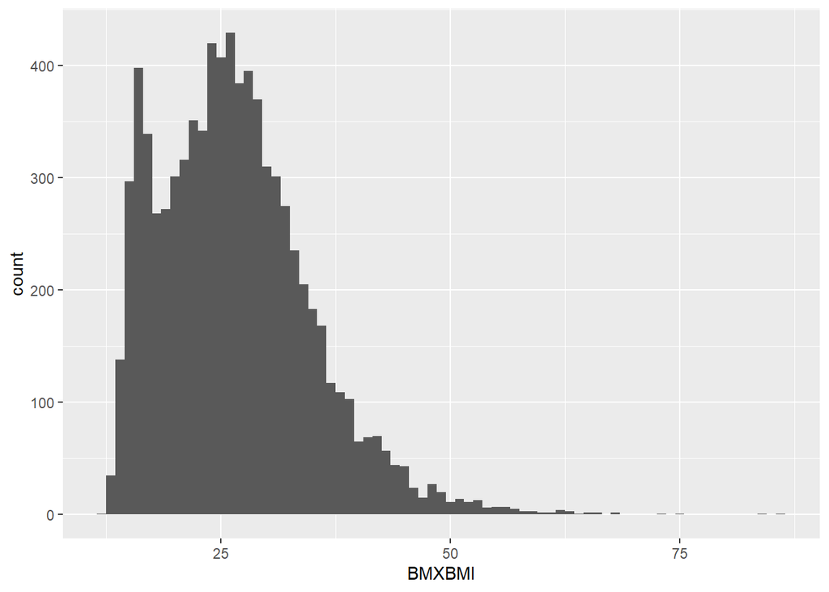

```r
ggplot(D_BMI, aes(x = BMXBMI)) + geom_histogram(binwidth = 1)
```

In NHNES 17-18, there are 8005 people’s BMI’s, ranging from 12.3 kg/m<sup>2</sup> to 86.2 kg/m<sup>2</sup>. The mean BMI is 26.58 kg/m<sup>2</sup> with a standard deviation of 8.26 kg/m<sup>2</sup>. The median is 25.8 kg/m<sup>2</sup> (IQR = 10.9 kg/m<sup>2</sup>) with a min of 12.3 kg/m<sup>2</sup> and a max of 86.2 kg/m<sup>2</sup>. The histogram is right skewed and centered at around 25 kg/m<sup>2</sup>.

## 2.2 Age

```r
S_age <- DVSW %>% select(SEQN, RIDAGEYR)

S_age %>% summarize(n = n(),
          mean = mean(RIDAGEYR),
          SD = sd(RIDAGEYR),
          median = median(RIDAGEYR),
          IQR = IQR(RIDAGEYR),
          min = min(RIDAGEYR),
          max = max(RIDAGEYR))
```

| n | mean | SD | median | IQR | min | max |
| --- | --- | --- | --- | --- | --- | --- |
| 9254 | 34.33423 | 25.50028 | 31 | 47 | 0 | 80 |

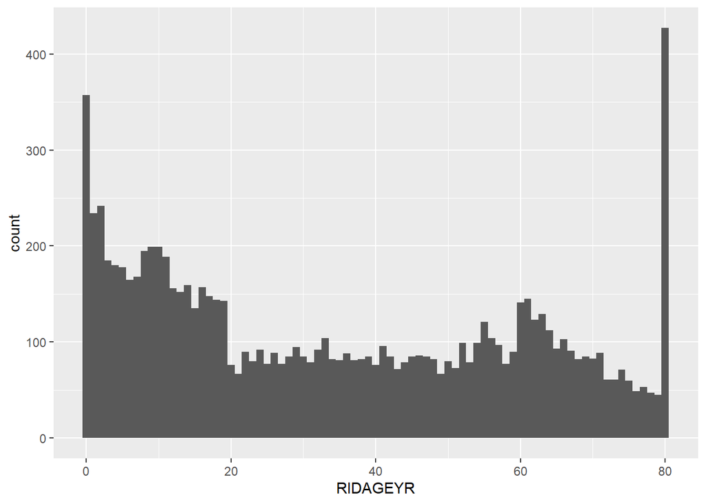

```r
ggplot(S_age, aes(x = RIDAGEYR)) + geom_histogram(binwidth = 1)
```

The average age of 9254 people included in NHNES 17-18 is 34.33 years and the median is 31 years (IQR = 47 years). The standard deviation is 25.5 years with a range from 0 years to 80 years. The histogram shows that there are a lot more people younger than one year old and older than 80.

## 2.3 Family monthly poverty level category

```r
S_IND <- INQ %>% filter(INDFMMPC <= 3) %>% select(SEQN, INDFMMPC)

S_IND %>% group_by(INDFMMPC) %>% summarize(n = n()) %>% mutate(prop = round(n/sum(n), 3))
```

| INDFMMPC | n | prop |
| --- | --- | --- |
| 1 | 3132 | 0.380 |
| 2 | 1346 | 0.163 |
| 3 | 3759 | 0.456 |

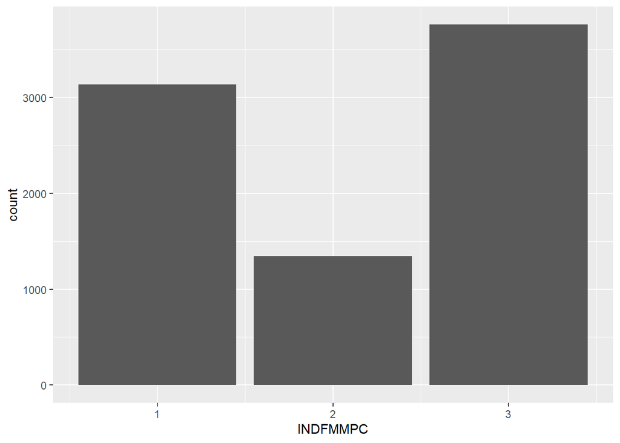

```r
ggplot(S_IND, aes(x = INDFMMPC)) + geom_bar()
```

8237 people were classified into family monthly poverty level category based on the family monthly poverty level index in NHNES 17-18. There are 3132 people having monthly poverty level index no more than 1.30 (38%) and 1346 people in the level index from 1.30 to 1.85 (16.3%). The other people were classified in the group of monthly poverty level index greater than 1.85 (45.6%).

## 2.4 Time of sitting in a typical day

```r
S_sedent <- PAQ %>% filter(PAD680 <= 1320) %>% select(SEQN, PAD680)

S_sedent %>% summarize(n = n(),
          mean = mean(PAD680),
          SD = sd(PAD680),
          median = median(PAD680),
          IQR = IQR(PAD680),
          min = min(PAD680),
          max = max(PAD680))
```

| n | mean | SD | median | IQR | min | max |
| --- | --- | --- | --- | --- | --- | --- |
| 5811 | 331.6799 | 199.1486 | 300 | 300 | 0 | 1320 |

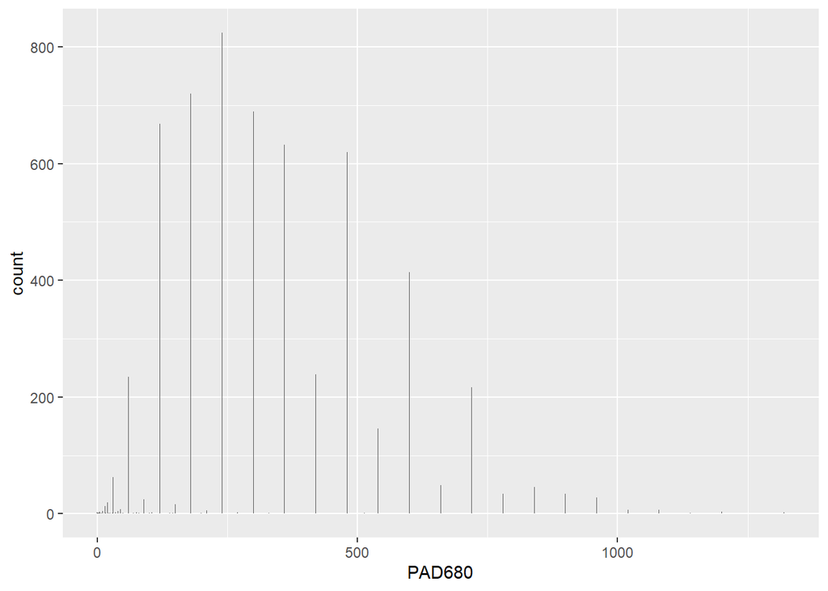

```r
ggplot(S_sedent, aes(x = PAD680)) + geom_histogram(binwidth = 1)
```

5811 people answered the question how much time they usually spend sitting on a typical day in the NHNES 17-18. The average time of people spending sitting on a typical day is 331.68 minutes (about 5.5 hours). The median time of people spending sitting on a typical day is 300 minutes (5 hours) with IQR of 300 minutes (min = 0 minutes, max = 1320 minutes). The standard deviation is 199.15 minutes. The histogram is right skewed and the center is at 250 minutes.

## 2.5 Systolic blood pressure

```r
S_BPX <- BPX %>% drop_na(BPXSY1) %>%
  drop_na(BPXDI1) %>%
  select(SEQN, BPXSY1, BPXDI1)

S_BPX %>% summarize(n = n(),
          mean = mean(BPXSY1),
          SD = sd(BPXSY1),
          median = median(BPXSY1),
          IQR = IQR(BPXSY1),
          min = min(BPXSY1),
          max = max(BPXSY1))
```

| n | mean | SD | median | IQR | min | max |
| --- | --- | --- | --- | --- | --- | --- |
| 6302 | 121.331 | 19.9787 | 118 | 26 | 72 | 228 |

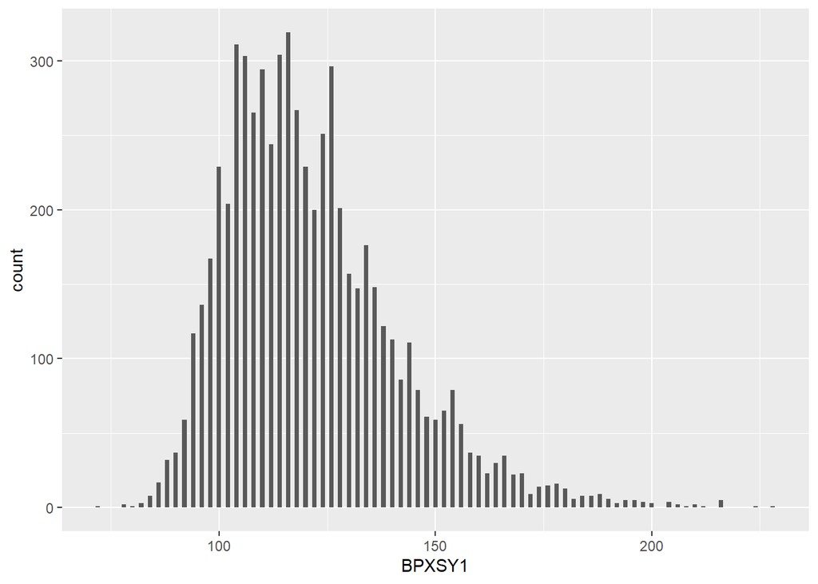

```r
ggplot(S_BPX, aes(x = BPXSY1)) + geom_histogram(binwidth = 1)
```

Among 6302 people in the NHNES 17-18, the average systolic blood pressure is 121.331 mm Hg with the standard deviation of 19.979 mm Hg. The median systolic blood pressure is 118 mm Hg (IQR = 26 mm Hg, min = 72 mm Hg, max = 228 mm Hg). The histogram is right skewed and centered at around 120 mm Hg.

## 2.6 Diastolic blood pressure

```r
S_BPX %>% summarize(n = n(),
          mean = mean(BPXDI1),
          SD = sd(BPXDI1),
          median = median(BPXDI1),
          IQR = IQR(BPXDI1),
          min = min(BPXDI1),
          max = max(BPXDI1))
```

| n | mean | SD | median | IQR | min | max |
| --- | --- | --- | --- | --- | --- | --- |
| 6302 | 67.84322 | 16.35989 | 70 | 16 | 0 | 136 |

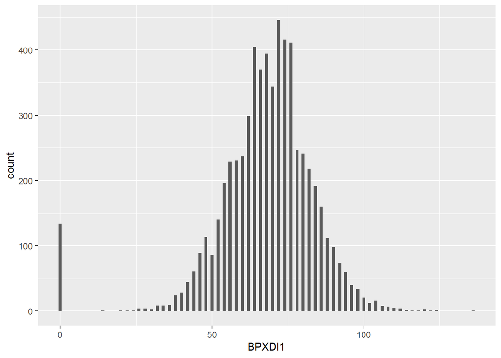

```r
ggplot(S_BPX, aes(x = BPXDI1)) + geom_histogram(binwidth = 1)
```

The diastolic blood pressure ranges from 0 mm Hg to 136 mm Hg. The average diastolic blood pressure is 67.843 mm Hg with a standard deviation of 16.36 mm Hg. The median diastolic blood pressure is 70 mm Hg (IQR = 16 mm Hg). The histogram is approximately bell shaped excluding the count of 0 mm Hg. The center is between 60 mm Hg and 70 mm Hg.

## 2.7 Total cholesterol

```r
S_TTL <- Total %>% drop_na(LBXTC) %>% select(SEQN, LBXTC)

S_TTL %>% summarize(n = n(),
          mean = mean(LBXTC),
          SD = sd(LBXTC),
          median = median(LBXTC),
          IQR = IQR(LBXTC),
          min = min(LBXTC),
          max = max(LBXTC))
```

| n | mean | SD | median | IQR | min | max |
| --- | --- | --- | --- | --- | --- | --- |
| 6738 | 179.8946 | 40.60225 | 176 | 53 | 76 | 446 |

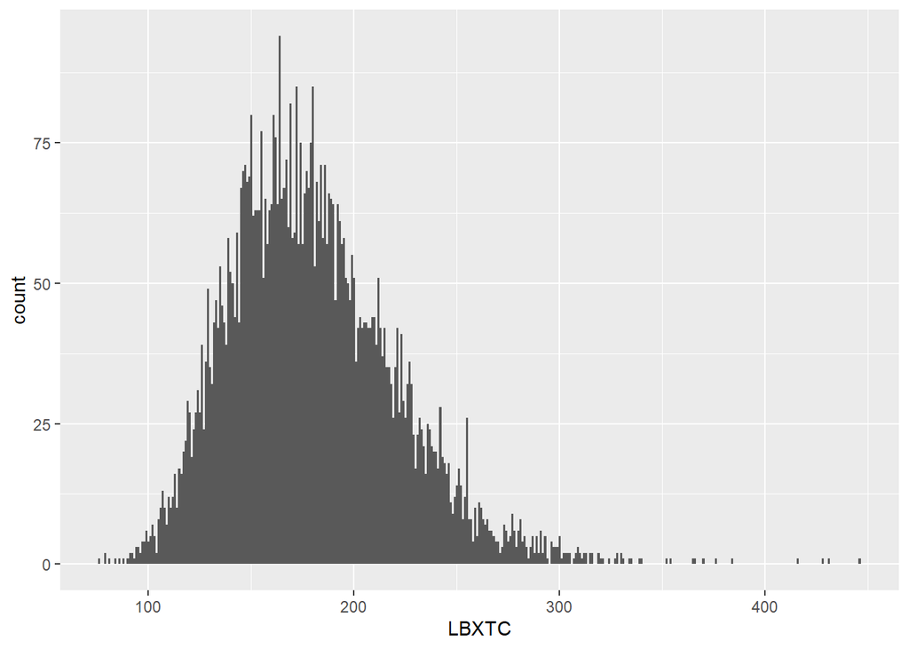

```r
ggplot(S_TTL, aes(x = LBXTC)) + geom_histogram(binwidth = 1)
```

There are 6738 people providing total cholesterol ranging from 76 mg/dL to 446 mg/dL. The mean of total cholesterol is 179.895 mg/dL with a standard deviation of 40.602 mg/dL and the median is 176 mg/dL (IQR = 53 mg/dL). The histogram is right skewed and center at around 180 mg/dL.

# 3 Bivariate relationship

## 3.1 BMI and Age

```r
injo_Ob_age <- inner_join(S_age, D_BMI, by = "SEQN")

with(injo_Ob_age, cor(RIDAGEYR, BMXBMI, use="pairwise.complete.obs"))
```

```
## [1] 0.4606843
```

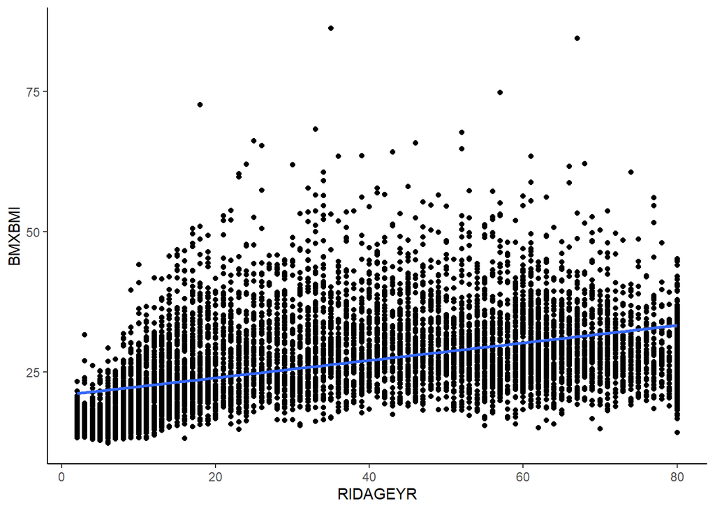

```r
ggplot(injo_Ob_age, aes(x = RIDAGEYR, y = BMXBMI)) + geom_point() +
  geom_smooth(method = "lm") +
  theme_classic()
```

```r
Ob_age_lm <- lm(BMXBMI ~ RIDAGEYR, data = injo_Ob_age)
summary(Ob_age_lm)
```

```
##
## Call:
## lm(formula = BMXBMI ~ RIDAGEYR, data = injo_Ob_age)
##
## Residuals:
##     Min      1Q  Median      3Q     Max
## -19.120  -5.163  -1.585   3.519  59.884
##
## Coefficients:
##              Estimate Std. Error t value Pr(>|t|)
## (Intercept) 20.869271   0.147746  141.25   <2e-16 ***
## RIDAGEYR     0.155631   0.003352   46.43   <2e-16 ***
## ---
## Signif. codes:  0 '***' 0.001 '**' 0.01 '*' 0.05 '.' 0.1 ' ' 1
##
## Residual standard error: 7.332 on 8003 degrees of freedom
## Multiple R-squared:  0.2122, Adjusted R-squared:  0.2121
## F-statistic:  2156 on 1 and 8003 DF,  p-value: < 2.2e-16
```

The correlation coefficient between BMI and age is around 0.46, which indicates a moderate positive correlation. The scatterplot also shows a positive association between people’s BMI and age. A high value of the person’s age tends to occur with a high value of BMI and a low value of the person’s age tends to occur with a low value of BMI.

b0 = 20.87

b1 = 0.156

Estimated regression equation is BMI_hat = 20.87 + 0.156 * Age.

Interpretation: A high value of age tends to occur with a high value of BMI.

Null hypothesis: the slope of the line describing age and BMI value is 0.

Alternative hypothesis: the slope of the line describing age and BMI value is not 0.

Test statistic: T = 46.43

P-value = 2*10^(-16) (< 0.05)

Decision: reject the null hypothesis

R-squared = 0.2122, which indicates that about 21.22% of the variation in the BMI can be explained by the linear relationship with age.

## 3.2 Obesity and age (subgroup)

```r
C_BMI <- D_BMI %>% drop_na(BMXBMI) %>%
  filter(BMXBMI > 30)  %>%
  select(SEQN, BMXBMI)


injo_Ob_age <- inner_join(C_BMI, S_age, by = "SEQN")

with(injo_Ob_age, cor(RIDAGEYR, BMXBMI, use="pairwise.complete.obs"))
```

```
## [1] -0.04727389
```

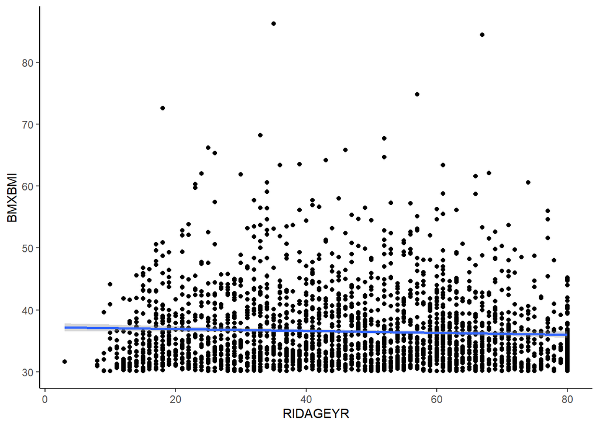

```r
ggplot(injo_Ob_age, aes(x = RIDAGEYR, y = BMXBMI)) + geom_point() +
  geom_smooth(method = "lm") +
  theme_classic()
```

```r
G_BMI <- D_BMI %>% drop_na(BMXBMI) %>%
  mutate(group = ifelse(BMXBMI >= 30, 1, 0)) %>%
  mutate(obesity_group = factor(group, level = c(0, 1), labels = c("No obesity", "Obesity"))) %>%
  select(SEQN, BMXBMI, obesity_group)

S_age <- DVSW %>%
  mutate(agegroup = ifelse(RIDAGEYR < 20, 1, 0)) %>%
  mutate(age_f = factor(agegroup, level = c(0, 1), labels = c("Older", "Younger"))) %>%
  select(SEQN, RIDAGEYR, age_f)

injo_Ob_age <- inner_join(G_BMI, S_age, by = "SEQN")

xtabs(~age_f + obesity_group, data = injo_Ob_age) %>% addmargins()
```

```
##          obesity_group
## age_f     No obesity Obesity  Sum
##   Older         3004    2171 5175
##   Younger       2593     237 2830
##   Sum           5597    2408 8005
```

```r
prop.test(x=c(2171, 237), n=c(5175, 2830), correct=FALSE, alternative = "greater")
```

```
##
##  2-sample test for equality of proportions without continuity correction
##
## data:  c(2171, 237) out of c(5175, 2830)
## X-squared = 980.69, df = 1, p-value < 2.2e-16
## alternative hypothesis: greater
## 95 percent confidence interval:
##  0.3216054 1.0000000
## sample estimates:
##     prop 1     prop 2
## 0.41951691 0.08374558
```

The correlation coefficient between BMI and age is around -0.047, which indicates a weak negative correlation. There is no obvious pattern shown in the scatter plot between BMI and age and the line is showing a slight negative association.

According to CDC[(reference)](https://www.cdc.gov/obesity/data/adult.html), the obesity prevalence was 39.8% among adults aged 20 to 39 years, 44.3% among adults aged 40 to 59 years, and 41.5% among adults aged 60 and older, so we investigate the obesity prevalence among people younger than 20 years and people at least 20 years.

Two sample Z test

Null hypothesis: the proportion of obesity in younger group (< 20) is the same as that in older group (>= 20).

Test statistic: Z = 31.316

P-value = 2.2*10^(-16)

Decision: to reject the null hypothesis

## 3.3 BMI and INDFMMPC

```r
G_BMI <- D_BMI %>% drop_na(BMXBMI) %>%
  mutate(group = ifelse(BMXBMI >= 30, 1, 0)) %>%
  mutate(obesity_group = factor(group, level = c(0, 1), labels = c("No obesity", "Obesity"))) %>%
  select(SEQN, BMXBMI, obesity_group)

injo_Ob_income <- drop_na(inner_join(S_IND, G_BMI, by = "SEQN"))

injo_Ob_income %>% group_by(INDFMMPC) %>%
  summarize(n = n(),
          mean = mean(BMXBMI),
          SD = sd(BMXBMI),
          median = median(BMXBMI),
          IQR = IQR(BMXBMI),
          min = min(BMXBMI),
          max = max(BMXBMI))
```

| INDFMMPC | n | mean | SD | median | IQR | min | max |
| --- | --- | --- | --- | --- | --- | --- | --- |
| 1 | 2701 | 25.97838 | 8.615749 | 24.7 | 11.800 | 12.3 | 84.4 |
| 2 | 1198 | 26.67162 | 8.184848 | 26.0 | 10.775 | 13.4 | 74.8 |
| 3 | 3318 | 26.82278 | 7.976472 | 26.2 | 10.200 | 12.6 | 86.2 |

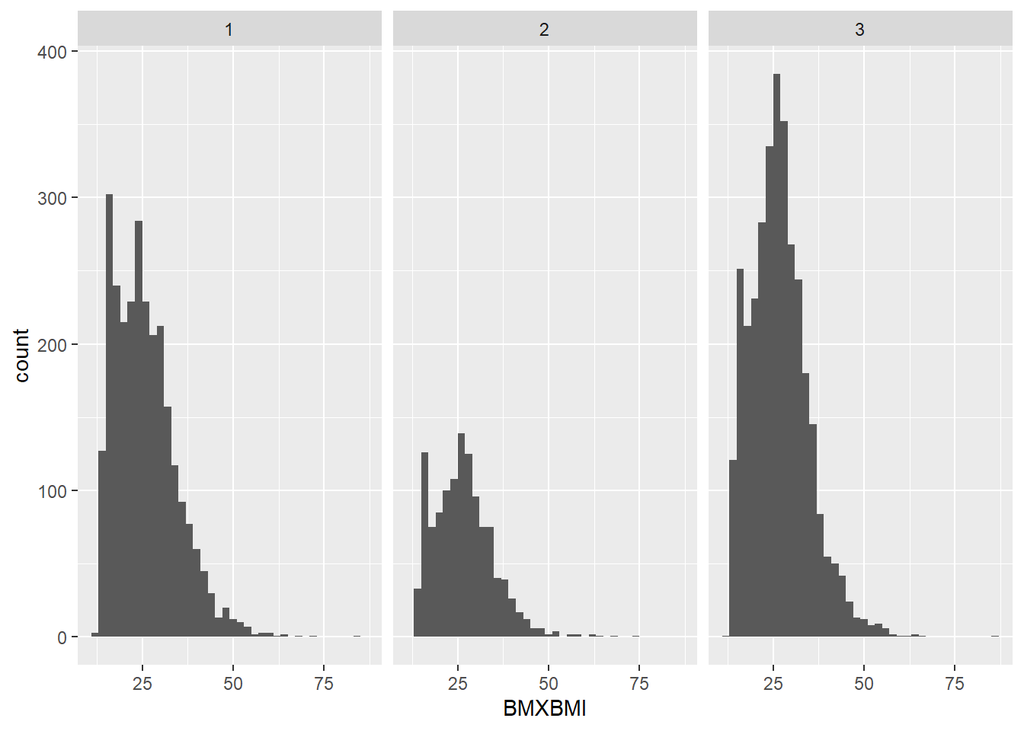

```r
ggplot(injo_Ob_income %>% drop_na(BMXBMI, INDFMMPC), aes(x=BMXBMI)) + geom_histogram(binwidth=2) + facet_wrap(~INDFMMPC)
```

In the group of family monthly poverty level index no more than 1.30, the average BMI is 25.98 kg/m<sup>2</sup> and the median is 24.7 kg/m<sup>2</sup> (IQR = 11.8 kg/m<sup>2</sup>). In the group of family monthly poverty level index from 1.30 to 1.85, the average BMI is 26.67 kg/m<sup>2</sup> and the median is 26.0 kg/m<sup>2</sup> (IQR = 10.775 kg/m<sup>2</sup>). In the group of family monthly poverty level index greater than 1.85, the average BMI is 26.82 kg/m<sup>2</sup> and the median is 26.2 kg/m<sup>2</sup> (IQR = 10.2 kg/m<sup>2</sup>). The difference between means of group 1 and group 2 is 0.69 kg/m<sup>2</sup>, the difference between means of group 2 and group 3 is 0.15 kg/m<sup>2</sup>, and the difference between means of group 1 and group 3 is 0.84 kg/m<sup>2</sup>. The pattern is that the higher family monthly poverty level index, the higher BMI value. Three side-by-side histograms are all right skewed and centered at around 25 kg/m<sup>2</sup>.

## 3.4 Obesity and INDFMMPC - subgroup

```r
injo_Ob_income <- drop_na(inner_join(S_IND, C_BMI, by = "SEQN")) %>%
  mutate(income_group = factor(INDFMMPC, level = c(1, 2, 3), labels = c("Index 1", "Index 2", "Index 3")))

injo_Ob_income %>% group_by(INDFMMPC) %>%
  summarize(n = n(),
          mean = mean(BMXBMI),
          SD = sd(BMXBMI),
          median = median(BMXBMI),
          IQR = IQR(BMXBMI),
          min = min(BMXBMI),
          max = max(BMXBMI))
```

| INDFMMPC | n | mean | SD | median | IQR | min | max |
| --- | --- | --- | --- | --- | --- | --- | --- |
| 1 | 754 | 36.92520 | 6.597305 | 35.1 | 7.60 | 30.1 | 84.4 |
| 2 | 355 | 36.41606 | 6.348646 | 34.5 | 6.35 | 30.1 | 74.8 |
| 3 | 1015 | 36.16000 | 5.926302 | 34.5 | 6.60 | 30.1 | 86.2 |

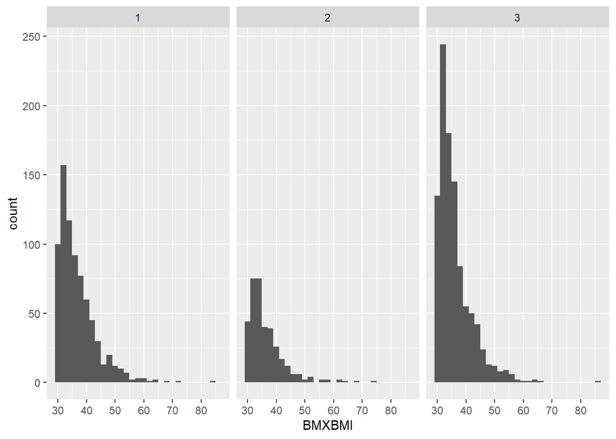

```r
ggplot(injo_Ob_income %>% drop_na(BMXBMI, INDFMMPC), aes(x = BMXBMI)) + geom_histogram(binwidth = 2) + facet_wrap(~INDFMMPC)
```

In the group of family monthly poverty level index no more than 1.30, the average BMI is 36.93 kg/m<sup>2</sup> and the median is 35.1 kg/m<sup>2</sup> (IQR = 7.6 kg/m<sup>2</sup>). In the group of family monthly poverty level index from 1.30 to 1.85, the average BMI is 36.42 kg/m<sup>2</sup> and the median is 34.5 kg/m<sup>2</sup> (IQR = 6.35 kg/m<sup>2</sup>). In the group of family monthly poverty level index greater than 1.85, the average BMI is 36.16 kg/m<sup>2</sup> and the median is 34.5 kg/m<sup>2</sup> (IQR = 6.6 kg/m<sup>2</sup>). The difference between means of group 1 and group 2 is -0.51 kg/m<sup>2</sup>, the difference between means of group 2 and group 3 is -0.25 kg/m<sup>2</sup>, and the difference between means of group 1 and group 3 is -0.77 kg/m<sup>2</sup>. The pattern is that for obese people, the higher family monthly poverty level index, the lower BMI value. Three side-by-side histograms are all right skewed and centered at around 35 kg/m<sup>2</sup>.

```r
model.formula <- lm(BMXBMI ~ income_group, data = injo_Ob_income)

model.emm <- emmeans(model.formula, pairwise ~ income_group, adjust = "bonferroni")
model.emm$contrasts
```

```
##  contrast          estimate    SE   df t.ratio p.value
##  Index 1 - Index 2    0.509 0.402 2121   1.267  0.6158
##  Index 1 - Index 3    0.765 0.300 2121   2.550  0.0326
##  Index 2 - Index 3    0.256 0.385 2121   0.665  1.0000
##
## P value adjustment: bonferroni method for 3 tests
```

```r
model.ci <- confint(model.emm, adjust="bonferroni", level = 0.95)$emmeans #default: level = 0.95
model.ci
```

|  | income_group | emmean | SE | df | lower.CL | upper.CL |
| --- | --- | --- | --- | --- | --- | --- |
| 1 | Index 1 | 36.92520 | 0.2273411 | 2121 | 36.38052 | 37.46988 |
| 2 | Index 2 | 36.41606 | 0.3313213 | 2121 | 35.62225 | 37.20986 |
| 3 | Index 3 | 36.16000 | 0.1959433 | 2121 | 35.69054 | 36.62946 |

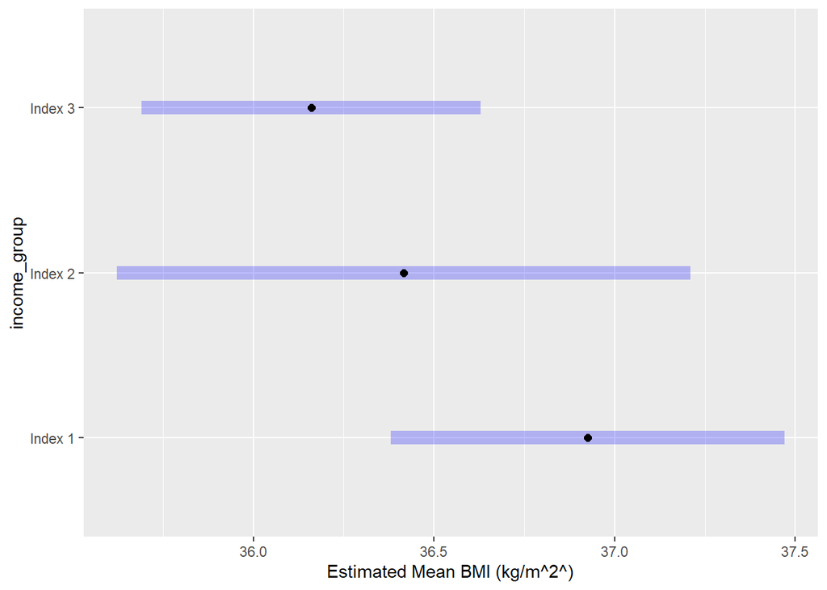

```r
plot(model.ci, xlab="Estimated Mean BMI (kg/m^2^)")
```

Bonferroni Comparisons

Under the significance level of 0.05, there is a BMI difference among obese people between family monthly poverty level indices 1 and 3. For index 1 group, the estimated average BMI is 36.9 kg/m<sup>2</sup>. The estimated average BMI’s for index 2 and 3 group are 36.4 and 36.2, representatively.

## 3.5 BMI and minutes of sedentary activity

```r
injo_Ob_sedent <- drop_na(inner_join(S_sedent, D_BMI, by = "SEQN"))

with(injo_Ob_sedent, cor(PAD680, BMXBMI, use="pairwise.complete.obs"))
```

```
## [1] 0.1117165
```

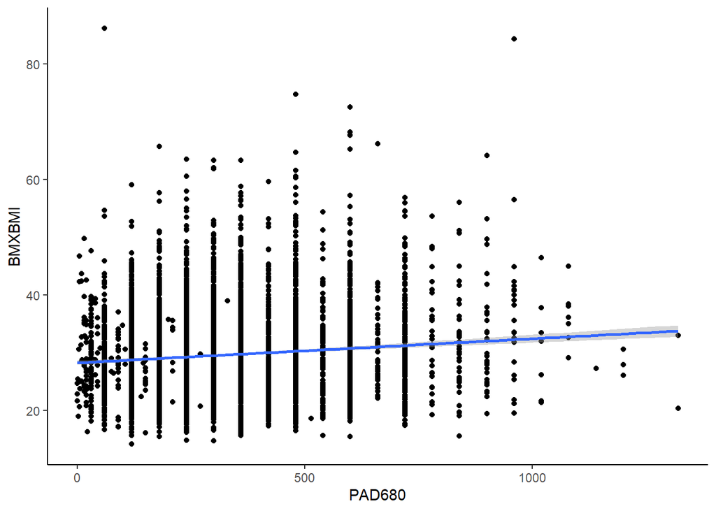

```r
ggplot(injo_Ob_sedent, aes(x = PAD680, y = BMXBMI)) + geom_point() +
  geom_smooth(method = "lm") +
  theme_classic()
```

The correlation coefficient between BMI and sitting time on a typical day is 0.1117, which indicates a weak positive association. The pattern in the scatter plot also shows a weak positive relationship between sitting time on a typical day (minutes) and BMI.

## 3.6 Obesity and minutes of sedentary activity - subgroup

```r
injo_Ob_sedent <- drop_na(inner_join(S_sedent, C_BMI, by = "SEQN"))

with(injo_Ob_sedent, cor(PAD680, BMXBMI, use="pairwise.complete.obs"))
```

```
## [1] 0.1119408
```

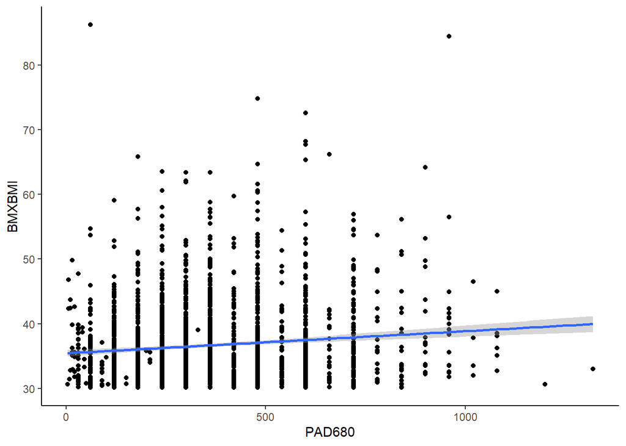

```r
ggplot(injo_Ob_sedent, aes(x = PAD680, y = BMXBMI)) + geom_point() +
  geom_smooth(method = "lm") +
  theme_classic()
```

```r
DVSW_gender <- DVSW %>%
  mutate(gender_f = factor(RIAGENDR, level = c(1, 2), labels = c("Male", "Female"))) %>%
  select(SEQN, RIAGENDR, gender_f)

injo_Ob_sedent <- drop_na(inner_join(S_sedent, G_BMI, by = "SEQN"))

injo_Ob_sedent <- drop_na(inner_join(DVSW_gender, injo_Ob_sedent, by = "SEQN"))

xtabs(~ gender_f + obesity_group, data = injo_Ob_sedent) %>% prop.table(margin = 2) %>% round(4)
```

```
##         obesity_group
## gender_f No obesity Obesity
##   Male       0.5016  0.4569
##   Female     0.4984  0.5431
```

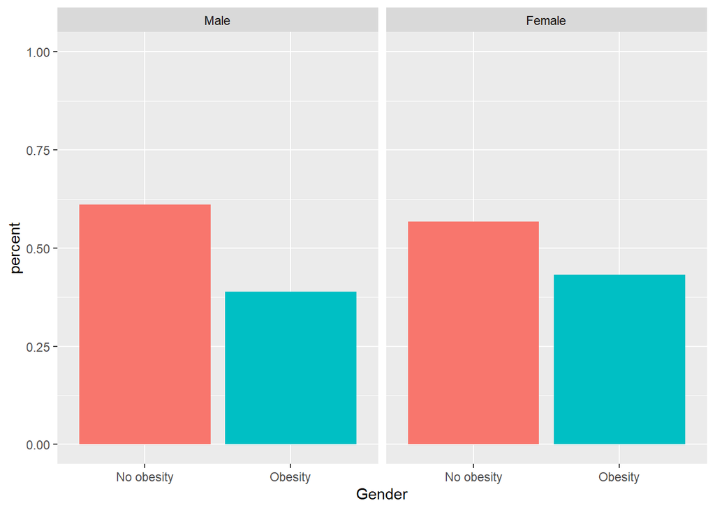

```r
plot_data <- injo_Ob_sedent %>% drop_na(gender_f, obesity_group) %>%
  group_by(gender_f, obesity_group) %>%
  tally %>%
  mutate(percent = n/sum(n))

ggplot(data = plot_data, aes(x = obesity_group, y = percent)) +
  geom_bar(stat="identity", aes(fill = obesity_group)) +
  theme(legend.position = "none") + # suppress legend
  xlab("Gender") + ylab("percent") +
  scale_y_continuous(limits=c(0,1)) + # force y-axis to be 0-1
  facet_wrap(. ~ gender_f)  # separate by mortality status
```

The correlation coefficient between BMI and sitting time on a typical day is 0.1119, which indicates a weak positive association. The pattern in the scatter plot also shows a weak positive relationship between sitting time on a typical day (minutes) and BMI.

### 3.6.1 Obesity and minutes of sedentary activity for females

```r
females <- injo_Ob_sedent %>% filter(gender_f == "Female")

females %>% filter(obesity_group == "Obesity") %>% summarize(n = n(),
          mean = mean(PAD680),
          SD = sd(PAD680),
          median = median(PAD680),
          IQR = IQR(PAD680),
          min = min(PAD680),
          max = max(PAD680))
```

| n | mean | SD | median | IQR | min | max |
| --- | --- | --- | --- | --- | --- | --- |
| 1204 | 349.9311 | 210.7687 | 300 | 300 | 3 | 1320 |

```r
females %>% filter(obesity_group == "No obesity") %>% summarize(n = n(),
          mean = mean(PAD680),
          SD = sd(PAD680),
          median = median(PAD680),
          IQR = IQR(PAD680),
          min = min(PAD680),
          max = max(PAD680))
```

| n | mean | SD | median | IQR | min | max |
| --- | --- | --- | --- | --- | --- | --- |
| 1584 | 311.928 | 185.9796 | 300 | 240 | 0 | 1320 |

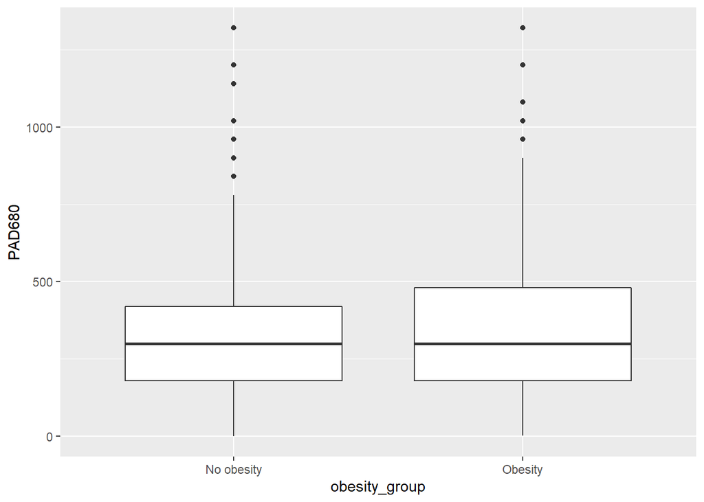

```r
ggplot(females %>% drop_na(gender_f, PAD680), aes(y=PAD680, x=obesity_group)) + geom_boxplot()
```

### 3.6.2 Obesity and minutes of sedentary activity for males

```r
males <- injo_Ob_sedent %>% filter(gender_f == "Male")

males %>% filter(obesity_group == "Obesity") %>% summarize(n = n(),
          mean = mean(PAD680),
          SD = sd(PAD680),
          median = median(PAD680),
          IQR = IQR(PAD680),
          min = min(PAD680),
          max = max(PAD680))
```

| n | mean | SD | median | IQR | min | max |
| --- | --- | --- | --- | --- | --- | --- |
| 1013 | 353.9042 | 202.2878 | 300 | 300 | 5 | 960 |

```r
males %>% filter(obesity_group == "No obesity") %>% summarize(n = n(),
          mean = mean(PAD680),
          SD = sd(PAD680),
          median = median(PAD680),
          IQR = IQR(PAD680),
          min = min(PAD680),
          max = max(PAD680))
```

| n | mean | SD | median | IQR | min | max |
| --- | --- | --- | --- | --- | --- | --- |
| 1594 | 320.5841 | 198.4349 | 300 | 300 | 0 | 1200 |

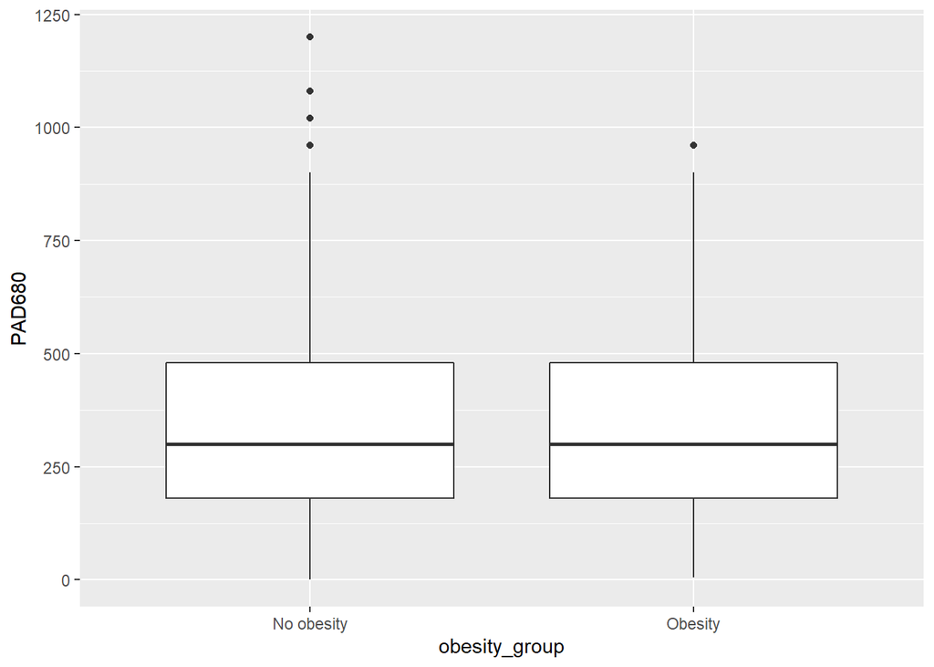

```r
ggplot(males %>% drop_na(gender_f, PAD680), aes(y = PAD680, x = obesity_group)) + geom_boxplot()
```

There are 1013 obese males in this data set and their average time of sedentary activity is 353.90 minutes. The standard deviation is 202.29 minutes and the median is 300 minutes (IQR = 300 minutes). The other 1594 non-obese males have the mean time of sedentary activity of 320.58 minutes with a standard deviation of 198.43 minutes. The median is 300 minutes (IQR = 300 minutes). There is no big difference between two ranges. The average time of sedentary activity for males without obesity is about 30 minutes lower than that for obese males as well.

## 3.7 BMI and SBP/DBP (hypertension)

```r
# systolic blood pressure (SBP) ≥ 140 mmHg or diastolic blood pressure (DBP) ≥ 90 mmHg

injo_Ob_hyper <- drop_na(inner_join(S_BPX, D_BMI, by = "SEQN"))

with(injo_Ob_hyper, cor(BMXBMI, BPXSY1, use="pairwise.complete.obs"))
```

```
## [1] 0.3092375
```

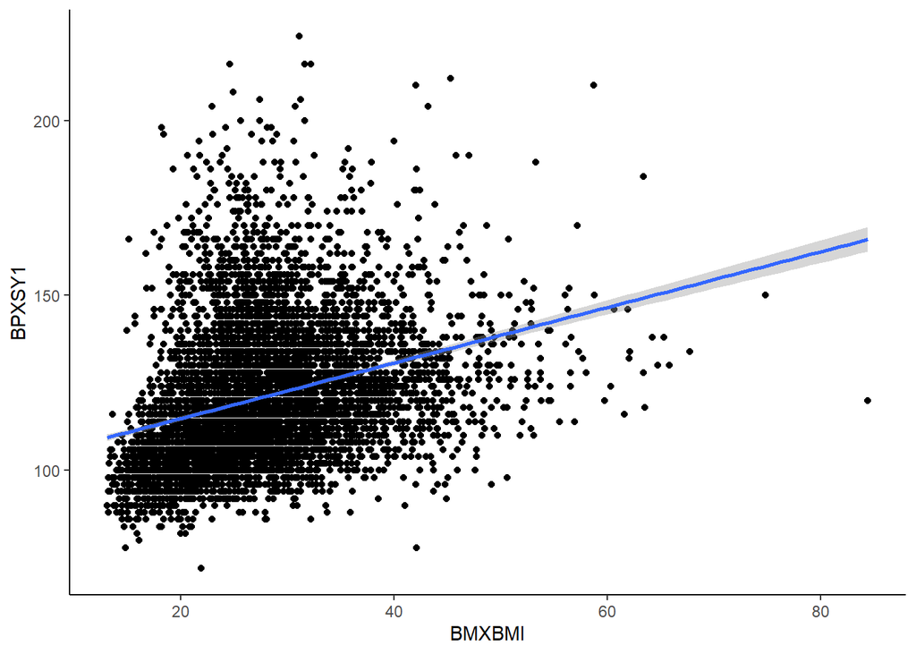

```r
ggplot(injo_Ob_hyper, aes(x=BMXBMI, y=BPXSY1)) +
  geom_point() +
  geom_smooth(method = "lm") +
  theme_classic()
```

```r
with(injo_Ob_hyper, cor(BMXBMI, BPXDI1, use="pairwise.complete.obs"))
```

```
## [1] 0.2685416
```

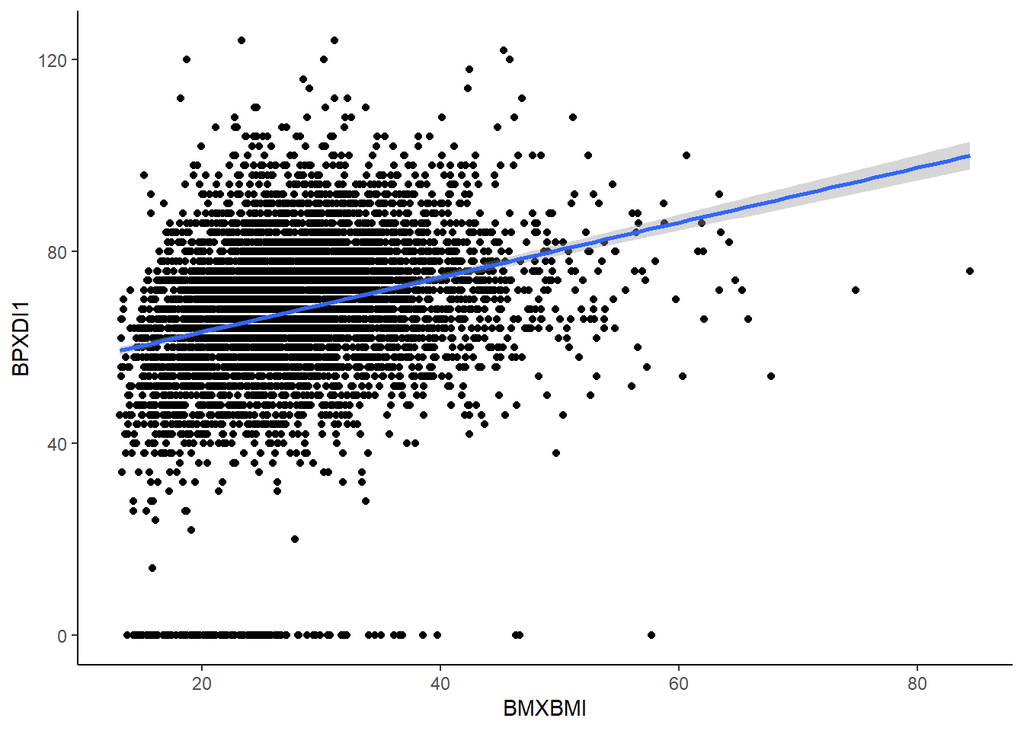

```r
ggplot(injo_Ob_hyper, aes(x=BMXBMI, y=BPXDI1)) +
  geom_point() +
  geom_smooth(method = "lm") +
  theme_classic()
```

The correlation coefficient between BMI and systolic blood pressure (SBP) is 0.3092, which indicates a moderate positive association. The pattern in the scatter plot also shows an obvious positive relationship between BMI and systolic blood pressure (SBP). The high value of BMI indicates the high value of SBP.

The correlation coefficient between BMI and diastolic blood pressure (DBP) is 0.2685, which indicates a weak positive association. The pattern in the scatter plot also shows an obvious positive relationship between BMI and DBP. The high value of BMI indicates the high value of DBP.

## 3.8 BMI and SBP (hypertension) - subgroup

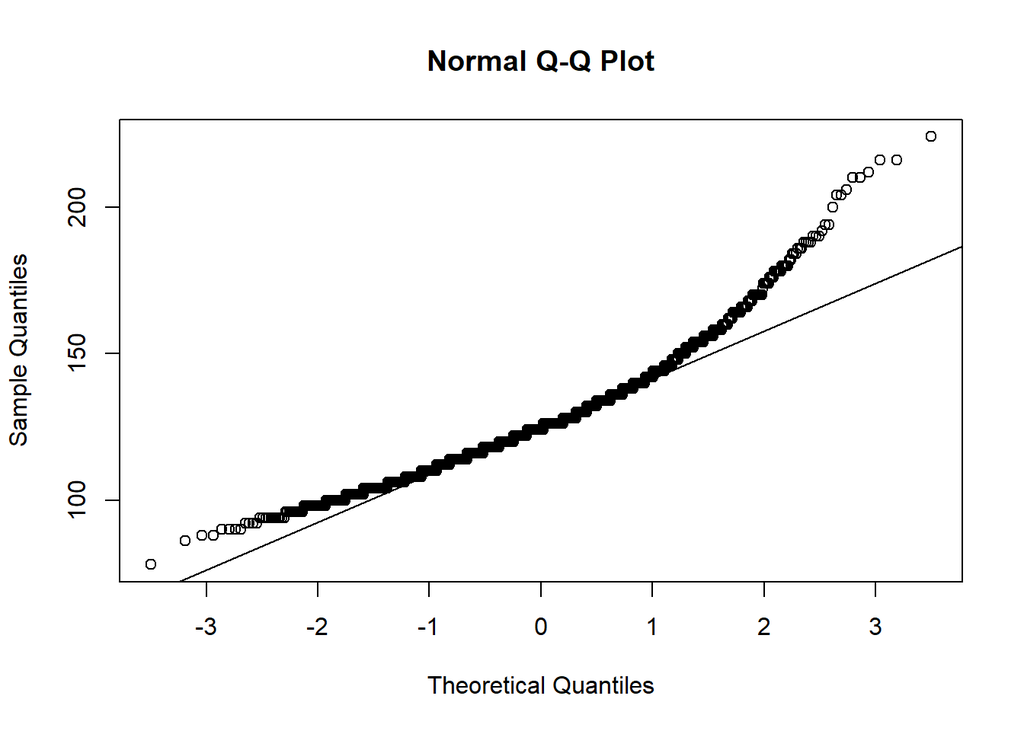

```r
injo_Ob_SBP <- drop_na(inner_join(S_BPX, G_BMI, by = "SEQN"))

obese_SBP <- injo_Ob_SBP %>% filter(obesity_group == "Obesity")

nonobese_SBP <- injo_Ob_SBP %>% filter(obesity_group == "No obesity")

qqnorm(obese_SBP$BPXSY1)
qqline(obese_SBP$BPXSY1)
```

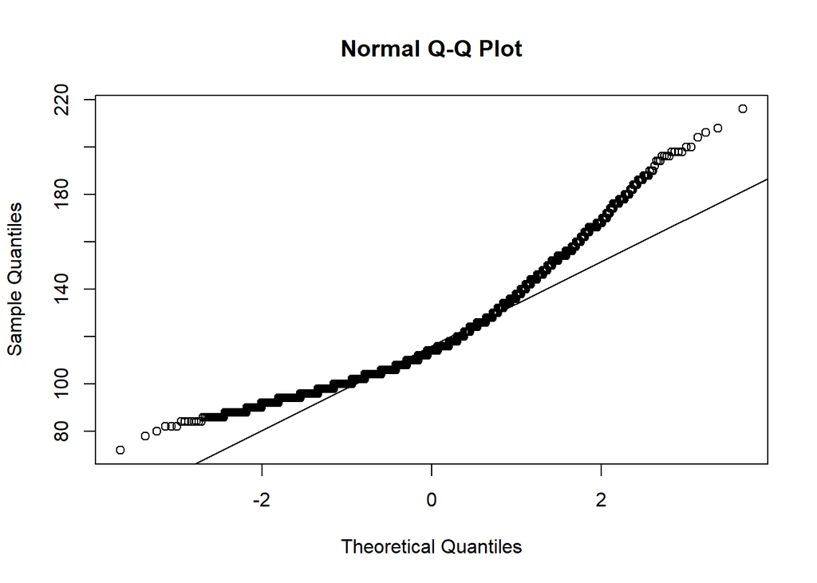

```r
qqnorm(nonobese_SBP$BPXSY1)
qqline(nonobese_SBP$BPXSY1)
```

```r
t.test(BPXSY1 ~ obesity_group, data = injo_Ob_SBP,
       alternative = "less",
       conf.level = 0.95)
```

```
##
##  Welch Two Sample t-test
##
## data:  BPXSY1 by obesity_group
## t = -17.308, df = 4598.1, p-value < 2.2e-16
## alternative hypothesis: true difference in means between group No obesity and group Obesity is less than 0
## 95 percent confidence interval:
##       -Inf -7.871723
## sample estimates:
## mean in group No obesity    mean in group Obesity
##                 118.2013                 126.8998
```

Two sample T test

Null hypothesis: The average systolic blood pressures are the same between the obese group and non-obese group.

Alternative hypothesis: The average systolic blood pressures in the non-obese group is smaller than that of the obese group.

Conditions:

Test statistics: t = -17.308

p-value = 2.2*10^(-16)

The decision is to reject the null hypothesis.

Conclusion: We have evidence saying that the average systolic blood pressures in the non-obese group is smaller than that of the obese group.

Interpretation of CI: We are 95% confident that the upper bound of the true difference for the average SBP between non-obese and obese groups is -7.87 mm Hg.

## 3.9 BMI and DBP (hypertension) - subgroup

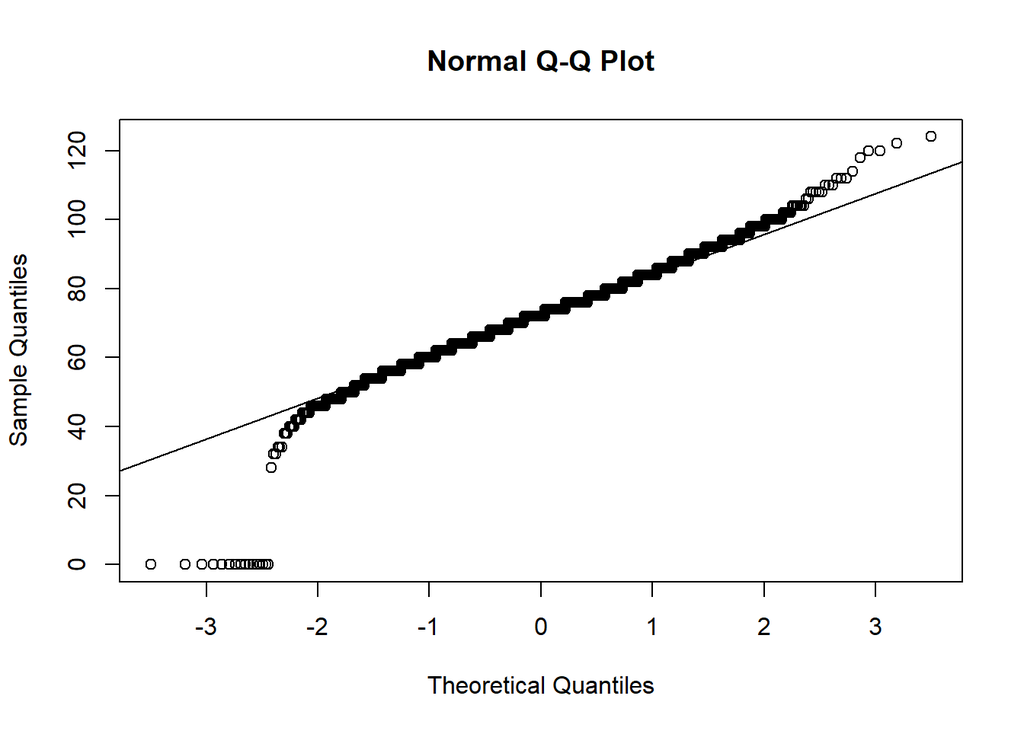

```r
injo_Ob_DBP <- drop_na(inner_join(S_BPX, G_BMI, by = "SEQN"))

obese_DBP <- injo_Ob_DBP %>% filter(obesity_group == "Obesity")

nonobese_DBP <- injo_Ob_DBP %>% filter(obesity_group == "No obesity")

qqnorm(obese_DBP$BPXDI1)
qqline(obese_DBP$BPXDI1)
```

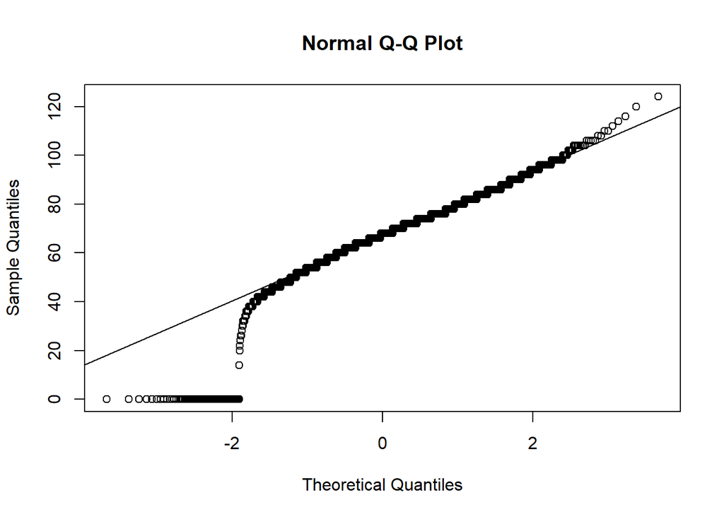

```r
qqnorm(nonobese_DBP$BPXDI1)
qqline(nonobese_DBP$BPXDI1)
```

```r
t.test(BPXDI1 ~ obesity_group, data = injo_Ob_DBP,
       alternative = "less",
       conf.level = 0.95)
```

```
##
##  Welch Two Sample t-test
##
## data:  BPXDI1 by obesity_group
## t = -16.363, df = 5056.3, p-value < 2.2e-16
## alternative hypothesis: true difference in means between group No obesity and group Obesity is less than 0
## 95 percent confidence interval:
##       -Inf -5.931304
## sample estimates:
## mean in group No obesity    mean in group Obesity
##                 65.56636                 72.16068
```

Two sample T test

Null hypothesis: The average diastolic blood pressures are the same between the obese group and non-obese group.

Alternative hypothesis: The average diastolic blood pressures in the non-obese group is smaller than that of the obese group.

Conditions:

Test statistics: t = -16.363

p-value = 2.2*10^(-16)

The decision is to reject the null hypothesis.

Conclusion: We have evidence saying that the average diastolic blood pressures in the non-obese group is smaller than that of the obese group.

Interpretation of CI: We are 95% confident that the upper bound of the true difference for the average DBP between non-obese and obese groups is -5.93 mm Hg.

## 3.10 BMI and total cholesterol

```r
#LBXTC >= 240 - High cholesterol level

injo_Ob_total <- drop_na(inner_join(S_TTL, D_BMI, by = "SEQN"))

with(injo_Ob_total, cor(BMXBMI, LBXTC, use="pairwise.complete.obs"))
```

```
## [1] 0.1499191
```

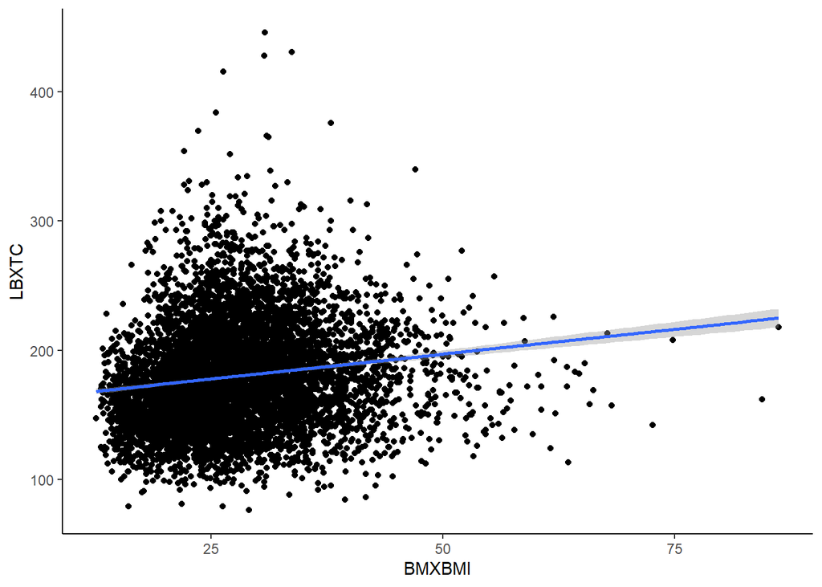

```r
ggplot(injo_Ob_total, aes(x = BMXBMI, y = LBXTC)) +
  geom_point() +
  geom_smooth(method = "lm") +
  theme_classic()
```

The correlation coefficient between BMI and total cholesterol is 0.15, which indicates a weak positive association. The high value of BMI indicates the high value of total cholesterol and the low value of BMI indicates the low value of total cholesterol. The pattern shows a positive relationship between BMI and total cholesterol.

```r
model_Ob_total <- lm(LBXTC ~ BMXBMI, data = injo_Ob_total)

summary(model_Ob_total)
```

```
##
## Call:
## lm(formula = LBXTC ~ BMXBMI, data = injo_Ob_total)
##
## Residuals:
##      Min       1Q   Median       3Q      Max
## -104.958  -28.263   -4.037   23.201  263.733
##
## Coefficients:
##              Estimate Std. Error t value Pr(>|t|)
## (Intercept) 158.54905    1.80352   87.91   <2e-16 ***
## BMXBMI        0.77005    0.06233   12.36   <2e-16 ***
## ---
## Signif. codes:  0 '***' 0.001 '**' 0.01 '*' 0.05 '.' 0.1 ' ' 1
##
## Residual standard error: 40.19 on 6639 degrees of freedom
## Multiple R-squared:  0.02248,    Adjusted R-squared:  0.02233
## F-statistic: 152.6 on 1 and 6639 DF,  p-value: < 2.2e-16
```

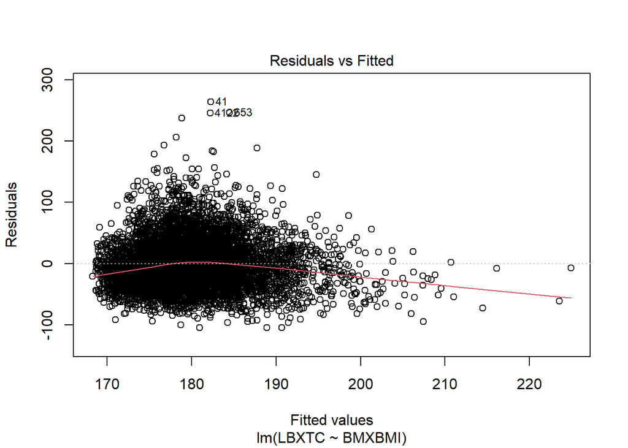

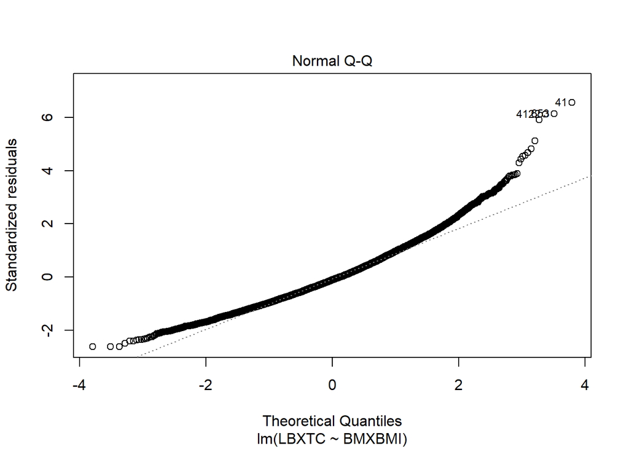

```r
plot(model_Ob_total, which=c(1:2))
```

Estimated linear regression: LBXTC = 0.77 * BMXBMI + 158.55

For each 1-point increase in BMI, the estimated people’s total cholesterol increases by 0.77.

The estimated total cholesterol of a person with his/her BMI of 0 is 158.55.

Assumptions:

Null hypothesis: the slope of the line describing LBXTC and BMI is 0

Alternative hypothesis: the slope of the line describing LBXTC is not 0

Test statistic: T = 12.36

p-value: 2*10^(-16)

Decision: Reject the null hypothesis

R-square = 2.25%, which indicates that about 2.25% of the variation in the total cholesterol can be explained by the linear relationship with patient’s body mass index. The variations cannot be explained by the estimated linear regression model very well.

```r
injo_Ob_total <- drop_na(inner_join(S_TTL, G_BMI, by = "SEQN"))

injo_Ob_total <- injo_Ob_total %>%
                      mutate(highCH = case_when(LBXTC < 240 ~ 0,
                                                       LBXTC >= 240 ~ 1))

xtabs(~obesity_group + highCH, data = injo_Ob_total) %>% addmargins()
```

```
##              highCH
## obesity_group    0    1  Sum
##    No obesity 4049  325 4374
##    Obesity    2061  206 2267
##    Sum        6110  531 6641
```

```r
tbl = xtabs(~obesity_group + highCH, data = injo_Ob_total)
chisq.test(tbl, correct=FALSE)
```

```
##
##  Pearson's Chi-squared test
##
## data:  tbl
## X-squared = 5.5703, df = 1, p-value = 0.01827
```

Chi-squared test of independence

Null hypothesis: the distribution of total cholesterol is independent of being obese or not.

Alternative hypothesis: the distribution of total cholesterol is dependent of being obese or not.

Conditions:

Test statistic: Q = 5.57

P-value = 0.018

Decision: to reject the null hypothesis

Conclusion: we have evidence that total cholesterol value depends upon BMI.

The prevalence of high cholesterol in the non-obese group is 7.43% and that in the obese group is 9.09%.